# Risk Factor Analysis

## Outcome Variable

**Outcome Variable:** stunted

## Predictor Variables

**Intervention Variable:** gagebrth

**Adjustment Set:**

unadjusted

## Stratifying Variables

The analysis was stratified on these variable(s):

- agecat
- studyid
- country

## Data Summary

| agecat | studyid | country | A | n | nA | nAY0 | nAY1 |
| --- | --- | --- | --- | --- | --- | --- | --- |
| Birth | ki1000108-CMC-V-BCS-2002 | INDIA | [273-287) | 90 | 35 | 28 | 7 |
| Birth | ki1000108-CMC-V-BCS-2002 | INDIA | <259 | 90 | 7 | 6 | 1 |
| Birth | ki1000108-CMC-V-BCS-2002 | INDIA | [259-273) | 90 | 22 | 19 | 3 |
| Birth | ki1000108-CMC-V-BCS-2002 | INDIA | >=287 | 90 | 26 | 21 | 5 |
| Birth | ki1000108-IRC | INDIA | [273-287) | 369 | 155 | 141 | 14 |
| Birth | ki1000108-IRC | INDIA | <259 | 369 | 36 | 27 | 9 |
| Birth | ki1000108-IRC | INDIA | [259-273) | 369 | 87 | 80 | 7 |
| Birth | ki1000108-IRC | INDIA | >=287 | 369 | 91 | 77 | 14 |
| Birth | ki1000109-EE | PAKISTAN | [273-287) | 2 | 0 | 0 | 0 |
| Birth | ki1000109-EE | PAKISTAN | <259 | 2 | 1 | 0 | 1 |
| Birth | ki1000109-EE | PAKISTAN | [259-273) | 2 | 1 | 1 | 0 |
| Birth | ki1000109-EE | PAKISTAN | >=287 | 2 | 0 | 0 | 0 |
| Birth | ki1017093c-NIH-Crypto | BANGLADESH | [273-287) | 27 | 12 | 10 | 2 |
| Birth | ki1017093c-NIH-Crypto | BANGLADESH | <259 | 27 | 3 | 1 | 2 |
| Birth | ki1017093c-NIH-Crypto | BANGLADESH | [259-273) | 27 | 11 | 10 | 1 |
| Birth | ki1017093c-NIH-Crypto | BANGLADESH | >=287 | 27 | 1 | 1 | 0 |
| Birth | ki1101329-Keneba | GAMBIA | [273-287) | 1515 | 592 | 572 | 20 |
| Birth | ki1101329-Keneba | GAMBIA | <259 | 1515 | 161 | 133 | 28 |
| Birth | ki1101329-Keneba | GAMBIA | [259-273) | 1515 | 592 | 560 | 32 |
| Birth | ki1101329-Keneba | GAMBIA | >=287 | 1515 | 170 | 168 | 2 |
| Birth | ki1135781-COHORTS | GUATEMALA | [273-287) | 290 | 114 | 110 | 4 |
| Birth | ki1135781-COHORTS | GUATEMALA | <259 | 290 | 49 | 44 | 5 |
| Birth | ki1135781-COHORTS | GUATEMALA | [259-273) | 290 | 46 | 44 | 2 |
| Birth | ki1135781-COHORTS | GUATEMALA | >=287 | 290 | 81 | 80 | 1 |
| Birth | ki1135781-COHORTS | INDIA | [273-287) | 1293 | 510 | 467 | 43 |
| Birth | ki1135781-COHORTS | INDIA | <259 | 1293 | 181 | 151 | 30 |
| Birth | ki1135781-COHORTS | INDIA | [259-273) | 1293 | 289 | 257 | 32 |
| Birth | ki1135781-COHORTS | INDIA | >=287 | 1293 | 313 | 294 | 19 |
| Birth | ki1135781-COHORTS | PHILIPPINES | [273-287) | 3024 | 1178 | 1141 | 37 |
| Birth | ki1135781-COHORTS | PHILIPPINES | <259 | 3024 | 459 | 383 | 76 |

[output cut: 234 more lines]

The following strata were considered:

- agecat: 12 months, studyid: ki1000108-CMC-V-BCS-2002, country: INDIA
- agecat: 12 months, studyid: ki1000108-IRC, country: INDIA
- agecat: 12 months, studyid: ki1000109-EE, country: PAKISTAN
- agecat: 12 months, studyid: ki1017093c-NIH-Crypto, country: BANGLADESH
- agecat: 12 months, studyid: ki1066203-TanzaniaChild2, country: TANZANIA, UNITED REPUBLIC OF
- agecat: 12 months, studyid: ki1101329-Keneba, country: GAMBIA
- agecat: 12 months, studyid: ki1113344-GMS-Nepal, country: NEPAL
- agecat: 12 months, studyid: ki1135781-COHORTS, country: GUATEMALA
- agecat: 12 months, studyid: ki1135781-COHORTS, country: INDIA
- agecat: 12 months, studyid: ki1135781-COHORTS, country: PHILIPPINES
- agecat: 18 months, studyid: ki1000108-CMC-V-BCS-2002, country: INDIA
- agecat: 18 months, studyid: ki1000108-IRC, country: INDIA
- agecat: 18 months, studyid: ki1000109-EE, country: PAKISTAN
- agecat: 18 months, studyid: ki1017093c-NIH-Crypto, country: BANGLADESH
- agecat: 18 months, studyid: ki1066203-TanzaniaChild2, country: TANZANIA, UNITED REPUBLIC OF
- agecat: 18 months, studyid: ki1101329-Keneba, country: GAMBIA
- agecat: 18 months, studyid: ki1113344-GMS-Nepal, country: NEPAL
- agecat: 18 months, studyid: ki1135781-COHORTS, country: GUATEMALA
- agecat: 18 months, studyid: ki1135781-COHORTS, country: PHILIPPINES
- agecat: 24 months, studyid: ki1000108-CMC-V-BCS-2002, country: INDIA
- agecat: 24 months, studyid: ki1000108-IRC, country: INDIA
- agecat: 24 months, studyid: ki1017093c-NIH-Crypto, country: BANGLADESH
- agecat: 24 months, studyid: ki1066203-TanzaniaChild2, country: TANZANIA, UNITED REPUBLIC OF
- agecat: 24 months, studyid: ki1101329-Keneba, country: GAMBIA
- agecat: 24 months, studyid: ki1113344-GMS-Nepal, country: NEPAL
- agecat: 24 months, studyid: ki1135781-COHORTS, country: GUATEMALA
- agecat: 24 months, studyid: ki1135781-COHORTS, country: INDIA
- agecat: 24 months, studyid: ki1135781-COHORTS, country: PHILIPPINES
- agecat: 3 months, studyid: ki1000108-CMC-V-BCS-2002, country: INDIA
- agecat: 3 months, studyid: ki1000108-IRC, country: INDIA
- agecat: 3 months, studyid: ki1000109-EE, country: PAKISTAN
- agecat: 3 months, studyid: ki1017093c-NIH-Crypto, country: BANGLADESH
- agecat: 3 months, studyid: ki1066203-TanzaniaChild2, country: TANZANIA, UNITED REPUBLIC OF
- agecat: 3 months, studyid: ki1101329-Keneba, country: GAMBIA
- agecat: 3 months, studyid: ki1113344-GMS-Nepal, country: NEPAL
- agecat: 3 months, studyid: ki1135781-COHORTS, country: GUATEMALA
- agecat: 3 months, studyid: ki1135781-COHORTS, country: INDIA
- agecat: 3 months, studyid: ki1135781-COHORTS, country: PHILIPPINES
- agecat: 6 months, studyid: ki1000108-CMC-V-BCS-2002, country: INDIA
- agecat: 6 months, studyid: ki1000108-IRC, country: INDIA
- agecat: 6 months, studyid: ki1000109-EE, country: PAKISTAN
- agecat: 6 months, studyid: ki1017093c-NIH-Crypto, country: BANGLADESH
- agecat: 6 months, studyid: ki1066203-TanzaniaChild2, country: TANZANIA, UNITED REPUBLIC OF
- agecat: 6 months, studyid: ki1101329-Keneba, country: GAMBIA
- agecat: 6 months, studyid: ki1113344-GMS-Nepal, country: NEPAL
- agecat: 6 months, studyid: ki1135781-COHORTS, country: GUATEMALA
- agecat: 6 months, studyid: ki1135781-COHORTS, country: INDIA
- agecat: 6 months, studyid: ki1135781-COHORTS, country: PHILIPPINES
- agecat: 9 months, studyid: ki1000108-CMC-V-BCS-2002, country: INDIA
- agecat: 9 months, studyid: ki1000108-IRC, country: INDIA
- agecat: 9 months, studyid: ki1000109-EE, country: PAKISTAN
- agecat: 9 months, studyid: ki1017093c-NIH-Crypto, country: BANGLADESH
- agecat: 9 months, studyid: ki1066203-TanzaniaChild2, country: TANZANIA, UNITED REPUBLIC OF
- agecat: 9 months, studyid: ki1101329-Keneba, country: GAMBIA
- agecat: 9 months, studyid: ki1113344-GMS-Nepal, country: NEPAL
- agecat: 9 months, studyid: ki1135781-COHORTS, country: GUATEMALA
- agecat: 9 months, studyid: ki1135781-COHORTS, country: INDIA
- agecat: 9 months, studyid: ki1135781-COHORTS, country: PHILIPPINES
- agecat: Birth, studyid: ki1000108-CMC-V-BCS-2002, country: INDIA
- agecat: Birth, studyid: ki1000108-IRC, country: INDIA
- agecat: Birth, studyid: ki1000109-EE, country: PAKISTAN
- agecat: Birth, studyid: ki1017093c-NIH-Crypto, country: BANGLADESH
- agecat: Birth, studyid: ki1101329-Keneba, country: GAMBIA
- agecat: Birth, studyid: ki1135781-COHORTS, country: GUATEMALA
- agecat: Birth, studyid: ki1135781-COHORTS, country: INDIA
- agecat: Birth, studyid: ki1135781-COHORTS, country: PHILIPPINES

### Dropped Strata

Some strata were dropped due to rare outcomes:

- agecat: Birth, studyid: ki1000108-CMC-V-BCS-2002, country: INDIA
- agecat: Birth, studyid: ki1000109-EE, country: PAKISTAN
- agecat: Birth, studyid: ki1017093c-NIH-Crypto, country: BANGLADESH
- agecat: Birth, studyid: ki1101329-Keneba, country: GAMBIA
- agecat: Birth, studyid: ki1135781-COHORTS, country: GUATEMALA
- agecat: 3 months, studyid: ki1000109-EE, country: PAKISTAN
- agecat: 3 months, studyid: ki1017093c-NIH-Crypto, country: BANGLADESH
- agecat: 3 months, studyid: ki1113344-GMS-Nepal, country: NEPAL
- agecat: 6 months, studyid: ki1000109-EE, country: PAKISTAN
- agecat: 6 months, studyid: ki1017093c-NIH-Crypto, country: BANGLADESH
- agecat: 6 months, studyid: ki1113344-GMS-Nepal, country: NEPAL
- agecat: 9 months, studyid: ki1000109-EE, country: PAKISTAN
- agecat: 9 months, studyid: ki1017093c-NIH-Crypto, country: BANGLADESH
- agecat: 9 months, studyid: ki1113344-GMS-Nepal, country: NEPAL
- agecat: 12 months, studyid: ki1000109-EE, country: PAKISTAN
- agecat: 12 months, studyid: ki1017093c-NIH-Crypto, country: BANGLADESH
- agecat: 12 months, studyid: ki1113344-GMS-Nepal, country: NEPAL
- agecat: 18 months, studyid: ki1000109-EE, country: PAKISTAN
- agecat: 18 months, studyid: ki1017093c-NIH-Crypto, country: BANGLADESH
- agecat: 18 months, studyid: ki1113344-GMS-Nepal, country: NEPAL
- agecat: 24 months, studyid: ki1017093c-NIH-Crypto, country: BANGLADESH
- agecat: 24 months, studyid: ki1066203-TanzaniaChild2, country: TANZANIA, UNITED REPUBLIC OF
- agecat: 24 months, studyid: ki1113344-GMS-Nepal, country: NEPAL

## Methods Detail

We’re interested in the causal parameters $E[Y_a]$ for all values of $a \in \mathcal{A}$. These parameters represent the mean outcome if, possibly contrary to fact, we intervened to set all units to have $A=a$. Under the randomization and positivity assumptions, these are identified by the statistical parameters $\psi_a=E_W[E_{Y|A,W}(Y|A=a,W)]$. In addition, we’re interested in the mean of $Y$, $E[Y]$ under no intervention (the observed mean). We will estimate these parameters by using SuperLearner to fit the relevant likelihood factors – $E_{Y|A,W}(Y|A=a,W)$ and $p(A=a|W)$, and then updating our likelihood fit using a joint TMLE.

For unadjusted analyses ($W=\{\}$), initial likelihoods were estimated using Lrnr_glm to estimate the simple $E(Y|A)$ and Lrnr_mean to estimate $p(A)$. For adjusted analyses, a small library containing Lrnr_glmnet, Lrnr_xgboost, and Lrnr_mean was used.

Having estimated these parameters, we will then use the delta method to estimate relative risks and attributable risks relative to a prespecified baseline level of $A$.

# Results Detail

## Results Plots

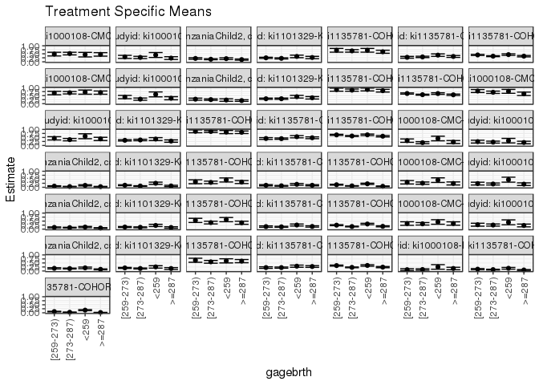

[figure not shown]

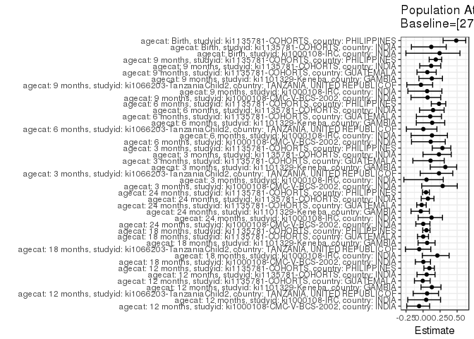

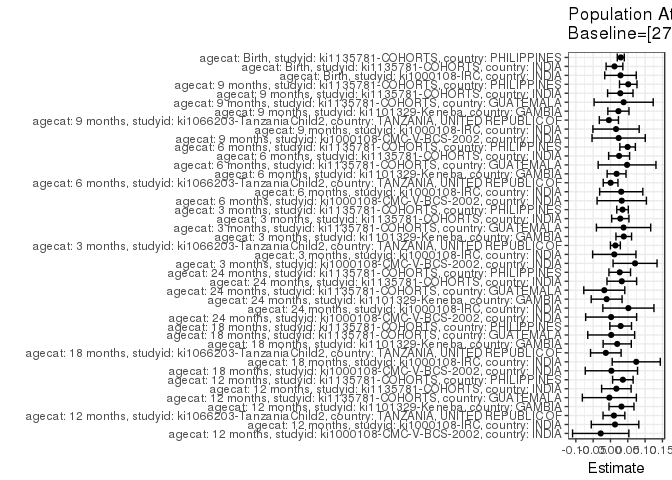

## Results Table

### Parameter: TSM

| agecat | studyid | country | intervention_level | baseline_level | estimate | ci_lower | ci_upper |
| --- | --- | --- | --- | --- | --- | --- | --- |
| Birth | ki1000108-IRC | INDIA | [273-287) | NA | 0.0903226 | 0.0451356 | 0.1355096 |
| Birth | ki1000108-IRC | INDIA | <259 | NA | 0.2500000 | 0.1083597 | 0.3916403 |
| Birth | ki1000108-IRC | INDIA | [259-273) | NA | 0.0804598 | 0.0232260 | 0.1376936 |
| Birth | ki1000108-IRC | INDIA | >=287 | NA | 0.1538462 | 0.0796153 | 0.2280770 |
| Birth | ki1135781-COHORTS | INDIA | [273-287) | NA | 0.0843137 | 0.0601895 | 0.1084380 |
| Birth | ki1135781-COHORTS | INDIA | <259 | NA | 0.1657459 | 0.1115523 | 0.2199394 |
| Birth | ki1135781-COHORTS | INDIA | [259-273) | NA | 0.1107266 | 0.0745348 | 0.1469185 |
| Birth | ki1135781-COHORTS | INDIA | >=287 | NA | 0.0607029 | 0.0342392 | 0.0871665 |
| Birth | ki1135781-COHORTS | PHILIPPINES | [273-287) | NA | 0.0314092 | 0.0214472 | 0.0413711 |
| Birth | ki1135781-COHORTS | PHILIPPINES | <259 | NA | 0.1655773 | 0.1315673 | 0.1995874 |
| Birth | ki1135781-COHORTS | PHILIPPINES | [259-273) | NA | 0.0756303 | 0.0576718 | 0.0935887 |
| Birth | ki1135781-COHORTS | PHILIPPINES | >=287 | NA | 0.0162455 | 0.0057168 | 0.0267742 |
| 3 months | ki1000108-CMC-V-BCS-2002 | INDIA | [273-287) | NA | 0.1760563 | 0.1133202 | 0.2387925 |
| 3 months | ki1000108-CMC-V-BCS-2002 | INDIA | <259 | NA | 0.4347826 | 0.2913154 | 0.5782498 |
| 3 months | ki1000108-CMC-V-BCS-2002 | INDIA | [259-273) | NA | 0.3013699 | 0.1959555 | 0.4067842 |
| 3 months | ki1000108-CMC-V-BCS-2002 | INDIA | >=287 | NA | 0.2151899 | 0.1244355 | 0.3059442 |
| 3 months | ki1000108-IRC | INDIA | [273-287) | NA | 0.2085890 | 0.1461346 | 0.2710433 |
| 3 months | ki1000108-IRC | INDIA | <259 | NA | 0.3000000 | 0.1578033 | 0.4421967 |
| 3 months | ki1000108-IRC | INDIA | [259-273) | NA | 0.2391304 | 0.1518557 | 0.3264052 |
| 3 months | ki1000108-IRC | INDIA | >=287 | NA | 0.1847826 | 0.1053711 | 0.2641941 |
| 3 months | ki1066203-TanzaniaChild2 | TANZANIA, UNITED REPUBLIC OF | [273-287) | NA | 0.0465394 | 0.0322738 | 0.0608049 |
| 3 months | ki1066203-TanzaniaChild2 | TANZANIA, UNITED REPUBLIC OF | <259 | NA | 0.1193548 | 0.0832564 | 0.1554533 |
| 3 months | ki1066203-TanzaniaChild2 | TANZANIA, UNITED REPUBLIC OF | [259-273) | NA | 0.0720524 | 0.0483658 | 0.0957390 |
| 3 months | ki1066203-TanzaniaChild2 | TANZANIA, UNITED REPUBLIC OF | >=287 | NA | 0.0399274 | 0.0235758 | 0.0562790 |
| 3 months | ki1101329-Keneba | GAMBIA | [273-287) | NA | 0.0788530 | 0.0564836 | 0.1012225 |
| 3 months | ki1101329-Keneba | GAMBIA | <259 | NA | 0.2516556 | 0.1824145 | 0.3208968 |
| 3 months | ki1101329-Keneba | GAMBIA | [259-273) | NA | 0.1289753 | 0.1013530 | 0.1565975 |
| 3 months | ki1101329-Keneba | GAMBIA | >=287 | NA | 0.0838323 | 0.0417855 | 0.1258792 |
| 3 months | ki1135781-COHORTS | GUATEMALA | [273-287) | NA | 0.3059701 | 0.2278358 | 0.3841045 |
| 3 months | ki1135781-COHORTS | GUATEMALA | <259 | NA | 0.4576271 | 0.3303223 | 0.5849319 |

[output cut: 142 more lines]

### Parameter: E(Y)

| agecat | studyid | country | intervention_level | baseline_level | estimate | ci_lower | ci_upper |
| --- | --- | --- | --- | --- | --- | --- | --- |
| Birth | ki1000108-IRC | INDIA | NA | NA | 0.1192412 | 0.1139626 | 0.1245198 |
| Birth | ki1135781-COHORTS | INDIA | NA | NA | 0.0959010 | 0.0941050 | 0.0976970 |
| Birth | ki1135781-COHORTS | PHILIPPINES | NA | NA | 0.0611772 | 0.0594211 | 0.0629334 |
| 3 months | ki1000108-CMC-V-BCS-2002 | INDIA | NA | NA | 0.2470588 | 0.2376920 | 0.2564256 |
| 3 months | ki1000108-IRC | INDIA | NA | NA | 0.2196382 | 0.2163325 | 0.2229440 |
| 3 months | ki1066203-TanzaniaChild2 | TANZANIA, UNITED REPUBLIC OF | NA | NA | 0.0607325 | 0.0596078 | 0.0618572 |
| 3 months | ki1101329-Keneba | GAMBIA | NA | NA | 0.1171983 | 0.1145427 | 0.1198540 |
| 3 months | ki1135781-COHORTS | GUATEMALA | NA | NA | 0.3437500 | 0.3382140 | 0.3492860 |
| 3 months | ki1135781-COHORTS | INDIA | NA | NA | 0.1215304 | 0.1198693 | 0.1231914 |
| 3 months | ki1135781-COHORTS | PHILIPPINES | NA | NA | 0.1228070 | 0.1208353 | 0.1247787 |
| 6 months | ki1000108-CMC-V-BCS-2002 | INDIA | NA | NA | 0.2910663 | 0.2840772 | 0.2980554 |
| 6 months | ki1000108-IRC | INDIA | NA | NA | 0.2371134 | 0.2289820 | 0.2452448 |
| 6 months | ki1066203-TanzaniaChild2 | TANZANIA, UNITED REPUBLIC OF | NA | NA | 0.0956385 | 0.0947475 | 0.0965294 |
| 6 months | ki1101329-Keneba | GAMBIA | NA | NA | 0.1317322 | 0.1298681 | 0.1335962 |
| 6 months | ki1135781-COHORTS | GUATEMALA | NA | NA | 0.4553314 | 0.4470775 | 0.4635853 |
| 6 months | ki1135781-COHORTS | INDIA | NA | NA | 0.1692073 | 0.1671756 | 0.1712390 |
| 6 months | ki1135781-COHORTS | PHILIPPINES | NA | NA | 0.2113882 | 0.2092113 | 0.2135651 |
| 9 months | ki1000108-CMC-V-BCS-2002 | INDIA | NA | NA | 0.3546512 | 0.3506744 | 0.3586279 |
| 9 months | ki1000108-IRC | INDIA | NA | NA | 0.2706186 | 0.2651649 | 0.2760722 |
| 9 months | ki1066203-TanzaniaChild2 | TANZANIA, UNITED REPUBLIC OF | NA | NA | 0.1464286 | 0.1449785 | 0.1478786 |
| 9 months | ki1101329-Keneba | GAMBIA | NA | NA | 0.1779230 | 0.1763472 | 0.1794988 |
| 9 months | ki1135781-COHORTS | GUATEMALA | NA | NA | 0.6072508 | 0.6034602 | 0.6110414 |
| 9 months | ki1135781-COHORTS | INDIA | NA | NA | 0.2384937 | 0.2363919 | 0.2405956 |
| 9 months | ki1135781-COHORTS | PHILIPPINES | NA | NA | 0.2746191 | 0.2725552 | 0.2766830 |
| 12 months | ki1000108-CMC-V-BCS-2002 | INDIA | NA | NA | 0.4855491 | 0.4828200 | 0.4882783 |
| 12 months | ki1000108-IRC | INDIA | NA | NA | 0.2875648 | 0.2821976 | 0.2929320 |
| 12 months | ki1066203-TanzaniaChild2 | TANZANIA, UNITED REPUBLIC OF | NA | NA | 0.1703540 | 0.1689137 | 0.1717943 |
| 12 months | ki1101329-Keneba | GAMBIA | NA | NA | 0.2469231 | 0.2449809 | 0.2488653 |
| 12 months | ki1135781-COHORTS | GUATEMALA | NA | NA | 0.6779661 | 0.6742202 | 0.6817120 |
| 12 months | ki1135781-COHORTS | INDIA | NA | NA | 0.3223214 | 0.3198090 | 0.3248339 |
| 12 months | ki1135781-COHORTS | PHILIPPINES | NA | NA | 0.3874366 | 0.3858209 | 0.3890523 |
| 18 months | ki1000108-CMC-V-BCS-2002 | INDIA | NA | NA | 0.6829971 | 0.6813072 | 0.6846870 |
| 18 months | ki1000108-IRC | INDIA | NA | NA | 0.3549223 | 0.3458846 | 0.3639600 |
| 18 months | ki1066203-TanzaniaChild2 | TANZANIA, UNITED REPUBLIC OF | NA | NA | 0.2386117 | 0.2365713 | 0.2406521 |
| 18 months | ki1101329-Keneba | GAMBIA | NA | NA | 0.3259032 | 0.3236722 | 0.3281341 |
| 18 months | ki1135781-COHORTS | GUATEMALA | NA | NA | 0.8428094 | 0.8396248 | 0.8459939 |
| 18 months | ki1135781-COHORTS | PHILIPPINES | NA | NA | 0.5876163 | 0.5861407 | 0.5890920 |
| 24 months | ki1000108-CMC-V-BCS-2002 | INDIA | NA | NA | 0.7114286 | 0.7049180 | 0.7179391 |
| 24 months | ki1000108-IRC | INDIA | NA | NA | 0.4153846 | 0.4091208 | 0.4216484 |
| 24 months | ki1101329-Keneba | GAMBIA | NA | NA | 0.3321799 | 0.3304391 | 0.3339208 |
| 24 months | ki1135781-COHORTS | GUATEMALA | NA | NA | 0.8531250 | 0.8504904 | 0.8557596 |
| 24 months | ki1135781-COHORTS | INDIA | NA | NA | 0.4579511 | 0.4556351 | 0.4602670 |
| 24 months | ki1135781-COHORTS | PHILIPPINES | NA | NA | 0.6175743 | 0.6161207 | 0.6190278 |

### Parameter: RR

| agecat | studyid | country | intervention_level | baseline_level | estimate | ci_lower | ci_upper |
| --- | --- | --- | --- | --- | --- | --- | --- |
| Birth | ki1000108-IRC | INDIA | [273-287) | [273-287) | 1.0000000 | 1.0000000 | 1.0000000 |
| Birth | ki1000108-IRC | INDIA | <259 | [273-287) | 2.7678571 | 1.2998454 | 5.8938031 |
| Birth | ki1000108-IRC | INDIA | [259-273) | [273-287) | 0.8908046 | 0.3733368 | 2.1255147 |
| Birth | ki1000108-IRC | INDIA | >=287 | [273-287) | 1.7032967 | 0.8500311 | 3.4130745 |
| Birth | ki1135781-COHORTS | INDIA | [273-287) | [273-287) | 1.0000000 | 1.0000000 | 1.0000000 |
| Birth | ki1135781-COHORTS | INDIA | <259 | [273-287) | 1.9658229 | 1.2730663 | 3.0355526 |
| Birth | ki1135781-COHORTS | INDIA | [259-273) | [273-287) | 1.3132695 | 0.8505432 | 2.0277356 |
| Birth | ki1135781-COHORTS | INDIA | >=287 | [273-287) | 0.7199643 | 0.4274080 | 1.2127725 |
| Birth | ki1135781-COHORTS | PHILIPPINES | [273-287) | [273-287) | 1.0000000 | 1.0000000 | 1.0000000 |
| Birth | ki1135781-COHORTS | PHILIPPINES | <259 | [273-287) | 5.2716246 | 3.6127475 | 7.6922136 |
| Birth | ki1135781-COHORTS | PHILIPPINES | [259-273) | [273-287) | 2.4079037 | 1.6202038 | 3.5785622 |
| Birth | ki1135781-COHORTS | PHILIPPINES | >=287 | [273-287) | 0.5172213 | 0.2513696 | 1.0642408 |
| 3 months | ki1000108-CMC-V-BCS-2002 | INDIA | [273-287) | [273-287) | 1.0000000 | 1.0000000 | 1.0000000 |
| 3 months | ki1000108-CMC-V-BCS-2002 | INDIA | <259 | [273-287) | 2.4695652 | 1.5195061 | 4.0136413 |
| 3 months | ki1000108-CMC-V-BCS-2002 | INDIA | [259-273) | [273-287) | 1.7117808 | 1.0389458 | 2.8203528 |
| 3 months | ki1000108-CMC-V-BCS-2002 | INDIA | >=287 | [273-287) | 1.2222785 | 0.7036948 | 2.1230293 |
| 3 months | ki1000108-IRC | INDIA | [273-287) | [273-287) | 1.0000000 | 1.0000000 | 1.0000000 |
| 3 months | ki1000108-IRC | INDIA | <259 | [273-287) | 1.4382353 | 0.8210097 | 2.5194840 |
| 3 months | ki1000108-IRC | INDIA | [259-273) | [273-287) | 1.1464194 | 0.7150336 | 1.8380641 |
| 3 months | ki1000108-IRC | INDIA | >=287 | [273-287) | 0.8858696 | 0.5246839 | 1.4956908 |
| 3 months | ki1066203-TanzaniaChild2 | TANZANIA, UNITED REPUBLIC OF | [273-287) | [273-287) | 1.0000000 | 1.0000000 | 1.0000000 |
| 3 months | ki1066203-TanzaniaChild2 | TANZANIA, UNITED REPUBLIC OF | <259 | [273-287) | 2.5645988 | 1.6672634 | 3.9448877 |
| 3 months | ki1066203-TanzaniaChild2 | TANZANIA, UNITED REPUBLIC OF | [259-273) | [273-287) | 1.5482029 | 0.9876949 | 2.4267941 |
| 3 months | ki1066203-TanzaniaChild2 | TANZANIA, UNITED REPUBLIC OF | >=287 | [273-287) | 0.8579274 | 0.5143874 | 1.4309050 |
| 3 months | ki1101329-Keneba | GAMBIA | [273-287) | [273-287) | 1.0000000 | 1.0000000 | 1.0000000 |
| 3 months | ki1101329-Keneba | GAMBIA | <259 | [273-287) | 3.1914509 | 2.1495930 | 4.7382732 |
| 3 months | ki1101329-Keneba | GAMBIA | [259-273) | [273-287) | 1.6356409 | 1.1463517 | 2.3337698 |
| 3 months | ki1101329-Keneba | GAMBIA | >=287 | [273-287) | 1.0631464 | 0.5975033 | 1.8916720 |
| 3 months | ki1135781-COHORTS | GUATEMALA | [273-287) | [273-287) | 1.0000000 | 1.0000000 | 1.0000000 |
| 3 months | ki1135781-COHORTS | GUATEMALA | <259 | [273-287) | 1.4956594 | 1.0252588 | 2.1818850 |

[output cut: 142 more lines]

### Parameter: PAR

| agecat | studyid | country | intervention_level | baseline_level | estimate | ci_lower | ci_upper |
| --- | --- | --- | --- | --- | --- | --- | --- |
| Birth | ki1000108-IRC | INDIA | [273-287) | NA | 0.0289186 | -0.0165757 | 0.0744129 |
| Birth | ki1135781-COHORTS | INDIA | [273-287) | NA | 0.0115873 | -0.0126037 | 0.0357783 |
| Birth | ki1135781-COHORTS | PHILIPPINES | [273-287) | NA | 0.0297681 | 0.0196525 | 0.0398837 |
| 3 months | ki1000108-CMC-V-BCS-2002 | INDIA | [273-287) | NA | 0.0710025 | 0.0075709 | 0.1344341 |
| 3 months | ki1000108-IRC | INDIA | [273-287) | NA | 0.0110493 | -0.0514925 | 0.0735911 |
| 3 months | ki1066203-TanzaniaChild2 | TANZANIA, UNITED REPUBLIC OF | [273-287) | NA | 0.0141931 | -0.0001167 | 0.0285029 |
| 3 months | ki1101329-Keneba | GAMBIA | [273-287) | NA | 0.0383453 | 0.0158188 | 0.0608718 |
| 3 months | ki1135781-COHORTS | GUATEMALA | [273-287) | NA | 0.0377799 | -0.0405504 | 0.1161101 |
| 3 months | ki1135781-COHORTS | INDIA | [273-287) | NA | 0.0283745 | 0.0034711 | 0.0532778 |
| 3 months | ki1135781-COHORTS | PHILIPPINES | [273-287) | NA | 0.0348852 | 0.0182249 | 0.0515455 |
| 6 months | ki1000108-CMC-V-BCS-2002 | INDIA | [273-287) | NA | 0.0325629 | -0.0386576 | 0.1037834 |
| 6 months | ki1000108-IRC | INDIA | [273-287) | NA | 0.0310528 | -0.0312755 | 0.0933811 |
| 6 months | ki1066203-TanzaniaChild2 | TANZANIA, UNITED REPUBLIC OF | [273-287) | NA | 0.0004004 | -0.0208454 | 0.0216462 |
| 6 months | ki1101329-Keneba | GAMBIA | [273-287) | NA | 0.0176637 | -0.0095768 | 0.0449042 |
| 6 months | ki1135781-COHORTS | GUATEMALA | [273-287) | NA | 0.0479240 | -0.0354896 | 0.1313376 |
| 6 months | ki1135781-COHORTS | INDIA | [273-287) | NA | 0.0249765 | -0.0052995 | 0.0552526 |
| 6 months | ki1135781-COHORTS | PHILIPPINES | [273-287) | NA | 0.0494834 | 0.0270924 | 0.0718744 |
| 9 months | ki1000108-CMC-V-BCS-2002 | INDIA | [273-287) | NA | 0.0236167 | -0.0531933 | 0.1004266 |
| 9 months | ki1000108-IRC | INDIA | [273-287) | NA | 0.0160731 | -0.0507018 | 0.0828480 |
| 9 months | ki1066203-TanzaniaChild2 | TANZANIA, UNITED REPUBLIC OF | [273-287) | NA | -0.0045730 | -0.0321660 | 0.0230201 |
| 9 months | ki1101329-Keneba | GAMBIA | [273-287) | NA | 0.0229415 | -0.0075767 | 0.0534597 |
| 9 months | ki1135781-COHORTS | GUATEMALA | [273-287) | NA | 0.0380200 | -0.0473153 | 0.1233553 |
| 9 months | ki1135781-COHORTS | INDIA | [273-287) | NA | 0.0284097 | -0.0082617 | 0.0650811 |
| 9 months | ki1135781-COHORTS | PHILIPPINES | [273-287) | NA | 0.0513457 | 0.0261512 | 0.0765402 |
| 12 months | ki1000108-CMC-V-BCS-2002 | INDIA | [273-287) | NA | -0.0281495 | -0.1093862 | 0.0530872 |
| 12 months | ki1000108-IRC | INDIA | [273-287) | NA | 0.0131745 | -0.0554152 | 0.0817642 |
| 12 months | ki1066203-TanzaniaChild2 | TANZANIA, UNITED REPUBLIC OF | [273-287) | NA | 0.0100486 | -0.0214095 | 0.0415068 |
| 12 months | ki1101329-Keneba | GAMBIA | [273-287) | NA | 0.0317836 | -0.0042288 | 0.0677960 |
| 12 months | ki1135781-COHORTS | GUATEMALA | [273-287) | NA | -0.0031933 | -0.0811469 | 0.0747602 |
| 12 months | ki1135781-COHORTS | INDIA | [273-287) | NA | 0.0170117 | -0.0255381 | 0.0595615 |
| 12 months | ki1135781-COHORTS | PHILIPPINES | [273-287) | NA | 0.0357882 | 0.0061589 | 0.0654176 |
| 18 months | ki1000108-CMC-V-BCS-2002 | INDIA | [273-287) | NA | 0.0027250 | -0.0727940 | 0.0782440 |
| 18 months | ki1000108-IRC | INDIA | [273-287) | NA | 0.0744345 | 0.0049999 | 0.1438691 |
| 18 months | ki1066203-TanzaniaChild2 | TANZANIA, UNITED REPUBLIC OF | [273-287) | NA | -0.0133990 | -0.0575308 | 0.0307327 |
| 18 months | ki1101329-Keneba | GAMBIA | [273-287) | NA | 0.0194515 | -0.0211973 | 0.0601004 |
| 18 months | ki1135781-COHORTS | GUATEMALA | [273-287) | NA | 0.0021014 | -0.0655595 | 0.0697623 |
| 18 months | ki1135781-COHORTS | PHILIPPINES | [273-287) | NA | 0.0294289 | -0.0018477 | 0.0607055 |
| 24 months | ki1000108-CMC-V-BCS-2002 | INDIA | [273-287) | NA | 0.0019691 | -0.0715693 | 0.0755076 |
| 24 months | ki1000108-IRC | INDIA | [273-287) | NA | 0.0517483 | -0.0220119 | 0.1255084 |
| 24 months | ki1101329-Keneba | GAMBIA | [273-287) | NA | -0.0110695 | -0.0556384 | 0.0334994 |
| 24 months | ki1135781-COHORTS | GUATEMALA | [273-287) | NA | -0.0178427 | -0.0769987 | 0.0413132 |
| 24 months | ki1135781-COHORTS | INDIA | [273-287) | NA | 0.0327084 | -0.0100685 | 0.0754852 |
| 24 months | ki1135781-COHORTS | PHILIPPINES | [273-287) | NA | 0.0267601 | -0.0044154 | 0.0579355 |

### Parameter: PAF

| agecat | studyid | country | intervention_level | baseline_level | estimate | ci_lower | ci_upper |
| --- | --- | --- | --- | --- | --- | --- | --- |
| Birth | ki1000108-IRC | INDIA | [273-287) | NA | 0.2425220 | -0.2516698 | 0.5415940 |
| Birth | ki1135781-COHORTS | INDIA | [273-287) | NA | 0.1208254 | -0.1711253 | 0.3399955 |
| Birth | ki1135781-COHORTS | PHILIPPINES | [273-287) | NA | 0.4865874 | 0.2940503 | 0.6266130 |
| 3 months | ki1000108-CMC-V-BCS-2002 | INDIA | [273-287) | NA | 0.2873910 | -0.0197223 | 0.5020100 |
| 3 months | ki1000108-IRC | INDIA | [273-287) | NA | 0.0503067 | -0.2816847 | 0.2963033 |
| 3 months | ki1066203-TanzaniaChild2 | TANZANIA, UNITED REPUBLIC OF | [273-287) | NA | 0.2336989 | -0.0417533 | 0.4363182 |
| 3 months | ki1101329-Keneba | GAMBIA | [273-287) | NA | 0.3271829 | 0.1056811 | 0.4938239 |
| 3 months | ki1135781-COHORTS | GUATEMALA | [273-287) | NA | 0.1099050 | -0.1496369 | 0.3108528 |
| 3 months | ki1135781-COHORTS | INDIA | [273-287) | NA | 0.2334765 | -0.0011953 | 0.4131432 |
| 3 months | ki1135781-COHORTS | PHILIPPINES | [273-287) | NA | 0.2840650 | 0.1352580 | 0.4072648 |
| 6 months | ki1000108-CMC-V-BCS-2002 | INDIA | [273-287) | NA | 0.1118745 | -0.1695142 | 0.3255601 |
| 6 months | ki1000108-IRC | INDIA | [273-287) | NA | 0.1309618 | -0.1752451 | 0.3573873 |
| 6 months | ki1066203-TanzaniaChild2 | TANZANIA, UNITED REPUBLIC OF | [273-287) | NA | 0.0041863 | -0.2446872 | 0.2032979 |
| 6 months | ki1101329-Keneba | GAMBIA | [273-287) | NA | 0.1340882 | -0.0993250 | 0.3179422 |
| 6 months | ki1135781-COHORTS | GUATEMALA | [273-287) | NA | 0.1052508 | -0.0978248 | 0.2707615 |
| 6 months | ki1135781-COHORTS | INDIA | [273-287) | NA | 0.1476091 | -0.0513496 | 0.3089167 |
| 6 months | ki1135781-COHORTS | PHILIPPINES | [273-287) | NA | 0.2340879 | 0.1207281 | 0.3328328 |
| 9 months | ki1000108-CMC-V-BCS-2002 | INDIA | [273-287) | NA | 0.0665913 | -0.1771284 | 0.2598498 |
| 9 months | ki1000108-IRC | INDIA | [273-287) | NA | 0.0593939 | -0.2226225 | 0.2763590 |
| 9 months | ki1066203-TanzaniaChild2 | TANZANIA, UNITED REPUBLIC OF | [273-287) | NA | -0.0312300 | -0.2380058 | 0.1410094 |
| 9 months | ki1101329-Keneba | GAMBIA | [273-287) | NA | 0.1289404 | -0.0605704 | 0.2845880 |
| 9 months | ki1135781-COHORTS | GUATEMALA | [273-287) | NA | 0.0626100 | -0.0889779 | 0.1930966 |
| 9 months | ki1135781-COHORTS | INDIA | [273-287) | NA | 0.1191213 | -0.0488102 | 0.2601643 |
| 9 months | ki1135781-COHORTS | PHILIPPINES | [273-287) | NA | 0.1869706 | 0.0899674 | 0.2736339 |
| 12 months | ki1000108-CMC-V-BCS-2002 | INDIA | [273-287) | NA | -0.0579746 | -0.2392517 | 0.0967854 |
| 12 months | ki1000108-IRC | INDIA | [273-287) | NA | 0.0458141 | -0.2250800 | 0.2568071 |
| 12 months | ki1066203-TanzaniaChild2 | TANZANIA, UNITED REPUBLIC OF | [273-287) | NA | 0.0589868 | -0.1450144 | 0.2266422 |
| 12 months | ki1101329-Keneba | GAMBIA | [273-287) | NA | 0.1287188 | -0.0299826 | 0.2629672 |
| 12 months | ki1135781-COHORTS | GUATEMALA | [273-287) | NA | -0.0047101 | -0.1265308 | 0.1039371 |
| 12 months | ki1135781-COHORTS | INDIA | [273-287) | NA | 0.0527787 | -0.0888460 | 0.1759824 |
| 12 months | ki1135781-COHORTS | PHILIPPINES | [273-287) | NA | 0.0923719 | 0.0126041 | 0.1656956 |
| 18 months | ki1000108-CMC-V-BCS-2002 | INDIA | [273-287) | NA | 0.0039898 | -0.1129510 | 0.1086432 |
| 18 months | ki1000108-IRC | INDIA | [273-287) | NA | 0.2097205 | -0.0114574 | 0.3825329 |
| 18 months | ki1066203-TanzaniaChild2 | TANZANIA, UNITED REPUBLIC OF | [273-287) | NA | -0.0561540 | -0.2583159 | 0.1135283 |
| 18 months | ki1101329-Keneba | GAMBIA | [273-287) | NA | 0.0596850 | -0.0736673 | 0.1764747 |
| 18 months | ki1135781-COHORTS | GUATEMALA | [273-287) | NA | 0.0024933 | -0.0811053 | 0.0796275 |
| 18 months | ki1135781-COHORTS | PHILIPPINES | [273-287) | NA | 0.0500819 | -0.0046577 | 0.1018388 |
| 24 months | ki1000108-CMC-V-BCS-2002 | INDIA | [273-287) | NA | 0.0027678 | -0.1061442 | 0.1009563 |
| 24 months | ki1000108-IRC | INDIA | [273-287) | NA | 0.1245791 | -0.0720995 | 0.2851767 |
| 24 months | ki1101329-Keneba | GAMBIA | [273-287) | NA | -0.0333238 | -0.1766029 | 0.0925077 |
| 24 months | ki1135781-COHORTS | GUATEMALA | [273-287) | NA | -0.0209146 | -0.0926670 | 0.0461261 |
| 24 months | ki1135781-COHORTS | INDIA | [273-287) | NA | 0.0714232 | -0.0268249 | 0.1602708 |
| 24 months | ki1135781-COHORTS | PHILIPPINES | [273-287) | NA | 0.0433309 | -0.0085003 | 0.0924983 |